# Predicting One family Dwelling Sale Prices

Kwasi Dankwa

## This is a linear regression project with aim of exploring one family dwellings in NYC. My interest was piqued after listening to a conversation on hot97 fm about the NYC housing crisis and as a student currently studying methods of data analysis in regression I felt this was a useful topic for practice.

```r
# installing and loading packages

library(readxl)
library(dplyr)
library(tidyverse)
library(stringr)
library(magrittr)
library(tidyr)
```

```r
# loading excel file for each borough
bronx <- read_excel('rollingsales_bronx.xlsx', skip = 4)
brooklyn <- read_excel('rollingsales_brooklyn.xlsx', skip = 4)
manhattan <- read_excel('rollingsales_manhattan.xlsx', skip = 4)
queens <- read_excel('rollingsales_queens.xlsx', skip = 4)
statenisland <- read_excel('rollingsales_statenisland.xlsx', skip = 4)
```

```r
# stack 5 data frames together
NYC_property_sales <- bind_rows(bronx, brooklyn, manhattan, queens, statenisland)

#removing data frames from each borough
rm(brooklyn, bronx, manhattan, statenisland, queens)

# Replace borough number with borough name, for clarity
NYC_property_sales <- NYC_property_sales %>%
  mutate(BOROUGH =
  case_when(BOROUGH == 1 ~ "Manhattan",
            BOROUGH == 2 ~ "Bronx",
            BOROUGH == 3 ~ "Brooklyn",
            BOROUGH == 4 ~ "Queens",
            BOROUGH == 5 ~ "Staten_Island"))
```

```r
#formatting data by converting column names to lower case-uniformity
colnames(NYC_property_sales) %<>% str_replace_all("\\s", "_") %>% tolower()

# convert capital columns to lower case
NYC_property_sales <- NYC_property_sales %>%
  mutate(neighborhood = str_to_title(neighborhood)) %>%
  mutate(building_class_category =
           str_to_title(building_class_category)) %>%
  mutate(address = str_to_title(address))
```

```r
# filtering data
NYC_property_sales <- NYC_property_sales %>%
  filter(sale_price > 10000) %>% #property exchanges between family members (assume threshold is 10000)
  filter(gross_square_feet > 0) %>% #removing gross square footage that is 0
  drop_na(gross_square_feet, sale_price)
```

```r
## Arranging boroughs and neighborhoods observations alphabetically
NYC_property_sales <- NYC_property_sales %>%
  arrange(borough, neighborhood)

write_csv(NYC_property_sales, "NYC_property_sales.csv")
```

```r
library(readr)
# Read in the CSV file we generated above
NYC_property_sales <- read_csv('NYC_property_sales.csv')
```

# Exploring bivariate relationships with scatterplot

```r
# looking for data with interesting points to select
sort(table(NYC_property_sales$building_class_at_present))
```

```
##
##   CB   G0   H2   H9   HR   HS   I1   I4   P3   P7   Q2   Q9   T2   W1   W3   Z0
##    1    1    1    1    1    1    1    1    1    1    1    1    1    1    1    1
##   C9   G8   I5   I7   I9   K6   M4   P2   P6   P8   W7   CC   F2   H7   H8   I6
##    2    2    2    2    2    2    2    2    2    2    2    3    3    3    3    3
##   D2   GW   H1   HB   K9   M3   O3   P5   S0   W9   H4   P9   W2   W8   Z3   G3
##    4    4    4    4    4    4    4    4    4    4    5    5    5    5    5    6
##   GU   D5   E2   N2   N9   O9   G9   K7   E7   A7   F1   G4   K5   M9   O1   D9
##    6    7    7    7    7    7    8    8    9   10   10   10   11   13   14   15
##   O4   H3   O8   Z9   F4   F9   D3   D6   G1   A6   M1   O2   D7   O6   O7   G2
##   15   16   16   17   22   23   24   26   26   31   34   34   35   35   41   49
##   C4   E9   F5   O5   S5   S4   C5   E1   S3   RR   D1   K2   S9   D8   S1   K4
##   52   52   55   55   59   64   77   80   81   87   91   94  110  140  157  165
##   C7   A4   A3   K1   A0   C2   C1   S2   C3   A9   B9   A2   B3   C0   B1   B2
##  166  167  200  218  268  289  291  365  417  542  713 1421 1724 1742 2028 2111
##   A5   A1
## 3094 3524
```

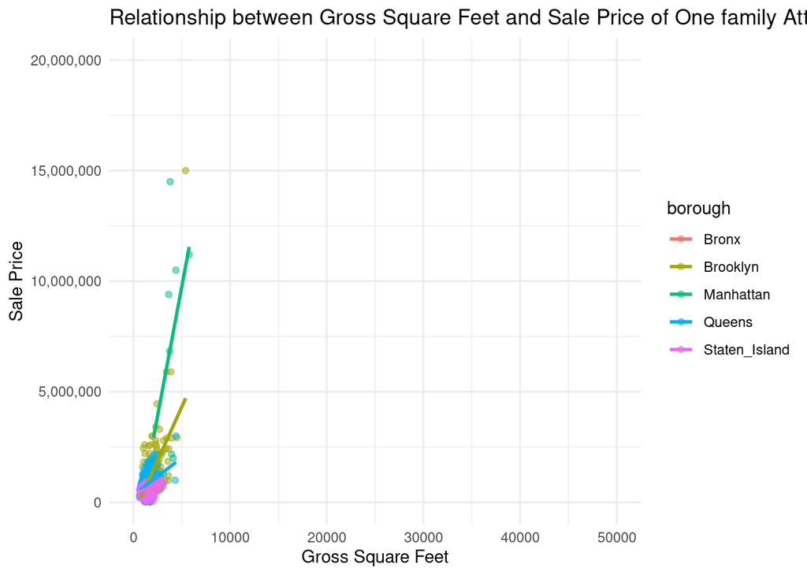

```r
#filter data to include condos with elevators(miscellaneous) designated as D9
NYC_family_attached <- NYC_property_sales %>%
  filter(building_class_at_time_of_sale == "A5")

# Create the scatterplot with customizations
library(ggplot2)
library(scales)
ggplot(NYC_family_attached, aes(x = gross_square_feet, y = sale_price, color = borough)) +
  geom_point(alpha = 0.5) +  # Add transparency to points
  geom_smooth(method = "lm", se = FALSE) +  # Add linear trend line without confidence intervals
  scale_y_continuous(labels = comma, limits = c(0, 20000000)) +  # Format y-axis without scientific notation and adjust limits
  xlim(0,50000) +  # Adjust x-axis limits
  theme_minimal() +  # Change to minimal theme (optional)
  labs(
    title = "Relationship between Gross Square Feet and Sale Price of One family Attached Residences",
    x = "Gross Square Feet",
    y = "Sale Price"
  )
```

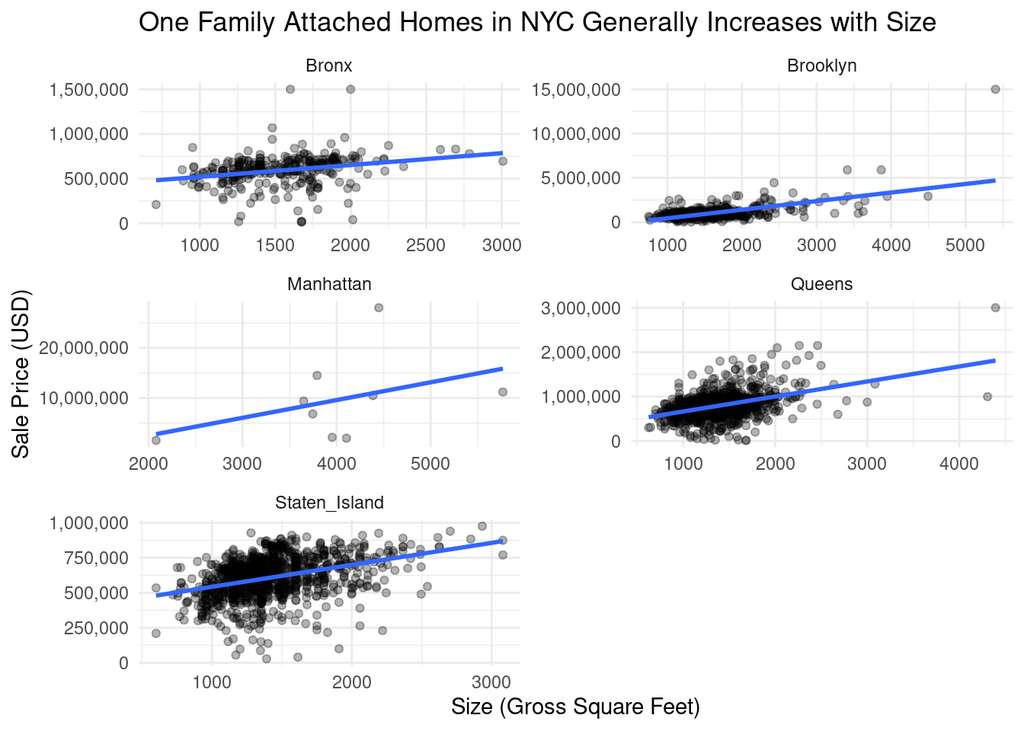

```r
# Zoom into data to better visualize for each borough
ggplot(data = NYC_family_attached,
       aes(x = gross_square_feet, y = sale_price)) +
  geom_point(alpha = 0.3) +
  facet_wrap(~ borough, scales = "free", ncol = 2) +
  scale_y_continuous(labels = scales::comma) +
  geom_smooth(method = "lm", se = FALSE) +
  theme_minimal() +
  labs(title = "One Family Attached Homes in NYC Generally Increases with Size",
       x = "Size (Gross Square Feet)",
       y = "Sale Price (USD)")
```

# Interpretation of One Family Attached units

- The graph shows the relationship between the size of one-family attached homes (measured in gross square feet) and their sale price in different boroughs of New York City (NYC).

General Observations:

Borough-Specific Observations:

- Manhattan: Homes in Manhattan have the highest sale prices overall and the steepest slope in the line, indicating a stronger relationship between size and price compared to other boroughs.
- Brooklyn: Shows a similar trend to Manhattan, with high prices and a steep slope.
- Queens: Also shows a positive correlation, but the slope is less steep than Manhattan and Brooklyn, suggesting that price increases less dramatically with size in Queens. Bronx: Homes in the Bronx have the lowest sale prices overall. The slope is less steep than Manhattan and Brooklyn, indicating a weaker relationship between size and price. Staten Island: Shows a positive correlation with a moderate slope, indicating a relationship between size and price that is less pronounced than in Manhattan and Brooklyn but more so than in the Bronx.

# Linear Regression model for family dwellings in all boroughs combined

```r
NYC_family_attachedlm <- lm(sale_price ~ gross_square_feet, data = NYC_family_attached)
summary(NYC_family_attachedlm)
```

```
##
## Call:
## lm(formula = sale_price ~ gross_square_feet, data = NYC_family_attached)
##
## Residuals:
##      Min       1Q   Median       3Q      Max
## -2246629  -226547     4833   180057 24632170
##
## Coefficients:
##                     Estimate Std. Error t value Pr(>|t|)
## (Intercept)       -487130.23   44485.01  -10.95   <2e-16 ***
## gross_square_feet     866.67      29.62   29.26   <2e-16 ***
## ---
## Signif. codes:  0 '***' 0.001 '**' 0.01 '*' 0.05 '.' 0.1 ' ' 1
##
## Residual standard error: 680100 on 3088 degrees of freedom
## Multiple R-squared:  0.2171, Adjusted R-squared:  0.2169
## F-statistic: 856.4 on 1 and 3088 DF,  p-value: < 2.2e-16
```

Gross square feet has a strong and significant positive relationship with sale price. However, the model explains only 21.71% of the variation, indicating that other important predictors might be useful in making predictions.

Intercept is -487130.23, with slope being 866.67 this means that for each additional square foot, the predicted sale price increases by approximately $866.67. The p-value (<2e-16) is extremely small, indicating that the variable is highly significant.

# Linear Regression for each borough

```r
# Create a list of models, one for each borough
models <- NYC_family_attached %>%
  group_by(borough) %>%
  do(model = lm(sale_price ~ gross_square_feet, data = .))
```

```r
install.packages('writexl')
library(writexl)

# view model summaries
results <- models %>%
  rowwise() %>%
  mutate(
    intercept = coef(model)[1],
    slope = coef(model)[2],
    r_squared = summary(model)$r.squared
  ) %>%
  select(borough, intercept, slope, r_squared)

# Write results to an Excel file
write_xlsx(results, path = "model_results.xlsx")
```

# Insights

## 3. Intercept Interpretation

Brooklyn and Manhattan have large negative intercepts: This suggests that at very low square footage values, the model predicts unrealistically negative sale prices. This might indicate that a non-linear model (e.g., log-transformation or polynomial regression) would work better.

Further Revisits of this model will try to incorporate adding additional predictor variables to make it a multiple linear regression model